# Chapter 1: Introduction to Signals

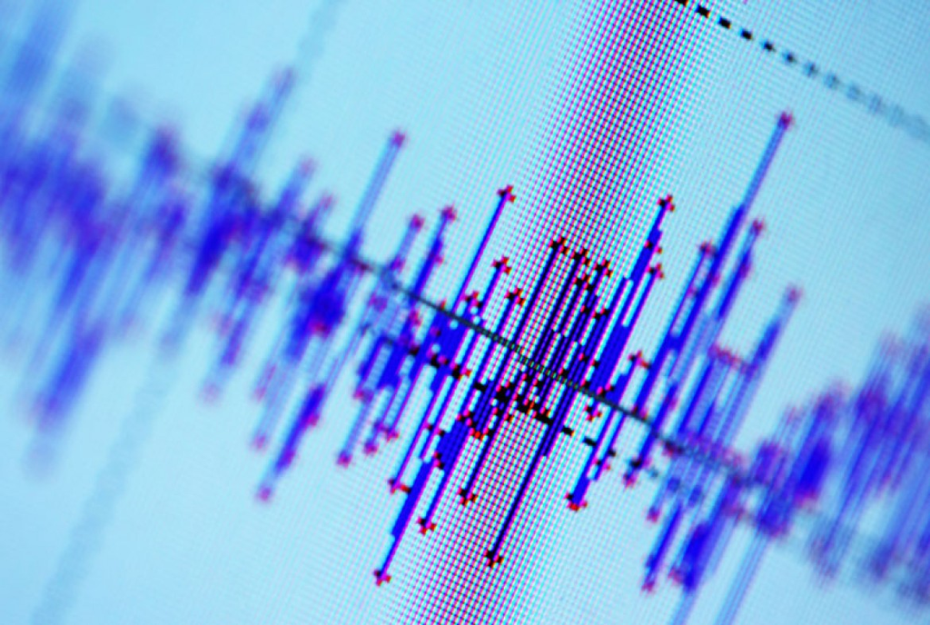

## **Signal Classifications and Properties**

### Introduction

This module will begin our study of signals and systems by laying out some of the fundamentals of signal classification. It is essentially an introduction to the important definitions and properties that are fundamental to the discussion of signals and systems, with a brief discussion of each.

## **Classification of Signals**

### Continuous-Time vs. Discrete Time

As the names suggest, this classification is determined by whether or not the time axis is **discrete** (countable) or **continuous** (*Figure 1.1*). A continuous-time signal will contain a value for all real numbers along the time axis. In contrast to this, a discrete-time signal, often created by sampling a continuous signal, will only have values at equally spaced intervals along the time axis.

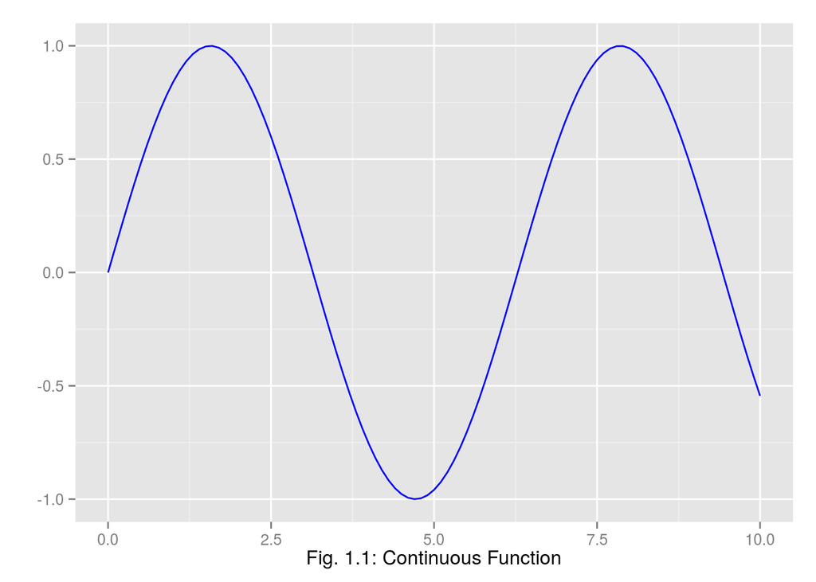

### Analog vs. Digital

The difference between **analog** and **digital** is similar to the difference between continuous-time and discrete-time. However, in this case the difference involves the values of the function. Analog corresponds to a continuous set of possible function values, while digital corresponds to a discrete set of possible function values. A common example of a digital signal is a *binary sequence*, where the values of the function can only be one or zero.

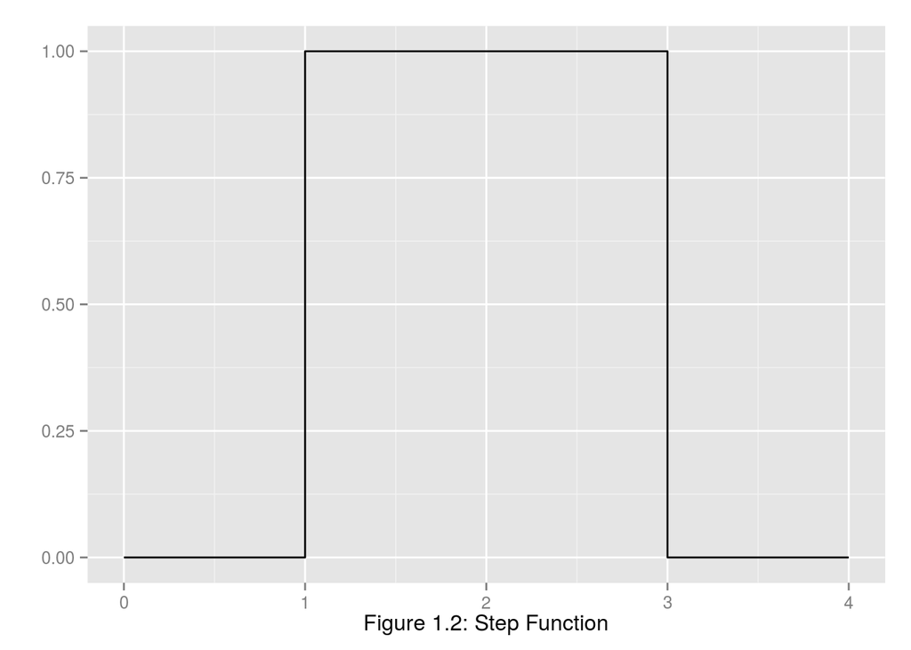

### Periodic vs. Aperiodic

$$f(t) = f(t + T)$$

The **fundamental period** of our funcion, $f(t)$, is the smallest value of $T$ that still allows (1.1) to be true.

### Finite vs. Infinite Length

Another way of classifying a signal is in terms of its length along its time axis. Is the signal defined for all possible values of time, or for only certain values of time? Mathematically speaking, $f(t)$ is a **finite-length signal** if it is **defined** only over a finite interval.

$$t_{1} < t < t_{2}$$

where t1 < t2. Similarly, an **infinite-length signal**, f(t), is defined for all values:

$$-\infty < t < \infty$$

### Even vs. Odd

Using the definitions of even and off signals, we can show that any signal can be written as a combination of an even and odd signal. That is, every signal has an odd-even decomposition. To demonstrate this, we have to look no farther than a single equation.

$$f(t) = \frac{1}{2} (f(t) + f(-t)) + \frac{1}{2} (f(t) - f(-t))$$

### Deterministic vs. Random

A **deterministic signal** is a signal in which each value of the signal is fixed, being determined by a mathematical expression, rule, or table. On the other hand, the values of a **random signal** are not strictly defined, but are subject to some amount of variability.

## **Signal Size and Norms**

### Introduction

The “size” of a signal would involve some notion of its strength. We use the mathematical concept of the norm to quantiy this for both continuous-time and discrete-time signals. As there are several types of norms that can be defined for signals, there are several different conceptions of signal size.

### Signal Energy

#### *Infinite Length, Continuous Time Signals*

The most commonly encountered notion of the energy of a signal defined on $\mathbb{R}$ is the $L_{2}$ norm defined by the square root of the integral of the square of the signal, for which the notation

$$||f||_{2} = (\int_{-\infty}^{\infty}{|f(t)|^{2} dt)^\frac{1}{2}}$$
However, this idea can be generalized through the definition of the $L_{p}$ norm, which is given by

$$||f||_{p} = (\int_{-\infty}^{\infty}{|f(t)|^{p} dt)^\frac{1}{p}}$$
for all $1 \leq p \leq \infty$. Because of the behavior of this expression as $p$ approaches $\infty$, we furthermore define

$$||f||_{\infty} = \underset{t\in \mathbb{R}}{sup} |f(t)|,$$

which is the least upper bound of $|f(t)|$. A signal $f$ is said to belong to the vector space $L_{p}(\mathbb{R})$ if $||f||_{p} \leq \infty$.

##### **Example 1.3**

For example, consider the function defined by

$$|x| = \left\{ \begin{array}{ll} 1/t & 1 \leq t \\ 0 & otherwise \end{array} \right.$$

The $L_{1}$ norm is

$$||f||_{1} = \int_{-\infty}^{\infty}|f(t)| dt = \int_{-\infty}^{\infty}\frac{1}{t}dt=\infty$$

The $L_{2}$ norm is

$$||f||_{2} = (\int_{-\infty}^{\infty}|f(t)|^{2} dt)^\frac{1}{2} = (\int_{-\infty}^{\infty}\frac{1}{t^{2}}dt^\frac{1}{2})= 1.$$

The $L_{\infty}$ norm is

$$||f||_{\infty} = \underset{t\in \mathbb{R}}{sup} |f(t)| = \underset{t\in \mathbb{R}[1,\infty)}{sup} \frac{1}{t} = 1.$$

#### *Finite Length, Continuous Time Signals*

The most commonly encountered notion of the energy of a signal defined on $\mathbb{R}[a,b]$ is the $L_{2}$ norm defined by the square root of the integral of the square of the signal, for which the notation is

$$||f||_{2} = (\int_{a}^{b}|f(t)|^{2}dt)^\frac{1}{2}.$$
However, this idea can be generalized through definition of the $L_{p}$ norm, which is given by

$$||f||_{p} = (\int_{a}^{b}|f(t)|^{p}dt)^\frac{1}{p}$$
for all $1 \leq p \leq \infty$. Because of the behavior of this expression as $p$ approaches $\infty$, we furthermore define

$$||f||_{\infty} = \underset{t\in \mathbb{R}[a,b]}{sup} |f(t)|,$$
which is the least upper bound of $|f(t)|$. A signal $f$ is said to belong to the vector space $L_{p} (\mathbb{R}[a,b])$ if $||f||_{p} < \infty$. The periodic extension of such a signal would have infinite energy but finite power.

##### **Example 1.4**

For example, consider the function defined on $\mathbb{R}[-5, 3]$ by

$$f(t) = \left\{ \begin{array}{ll} t & -5 \lt t \lt 3 \\ 0 & otherwise \end{array} \right.$$
The $L_{1}$ norm is

$$||f||_{1} = \int_{-5}^{3}|f(t)|dt| = \int_{-5}^{3}|t|dt = 17.$$
The $L_{2}$ norm is

$$||f||_{2} = (\int_{-5}^{3}|f(t)|^{2} dt)^\frac{1}{2} = (\int_{-5}^{3}|t|^{2}dt)^\frac{1}{2} \approx 7.12.$$
The $L_{\infty}$ norm is

$$||f||_{\infty} = \underset{t\in \mathbb{R}[-5,3]}{sup} |t| = 5.$$

#### *Infinite Length, Discrete Time Signals*

###### About: [Github Repo](http://www.github.com/dynamicwebpaige/signals-and-systems), [Richard Baraniuk](http://richb.rice.edu/signal-processing/)